[MLBAM’s website](http://gd2.mlb.com/components/game/mlb/) hosts a wealth of data that informs the [MLB Gameday application](http://mlb.mlb.com/mlb/scoreboard). Most notably, this website hosts pitch-by-pitch (ie, PITCHf/x) and play-by-play data. pitchRx provides a simple interface to acquire a good portion of Gameday data (see Table 1 of [my paper](http://journal.r-project.org/archive/accepted/sievert.pdf)), but there is a significant amount that isn’t accessible using `pitchRx::scrape`. This post will show you how to leverage both pitchRx and XML2R to acquire and manipulate data from this website (some of these techniques can be applied to any XML data source).

## Constructing Gameday urls

When scraping data off the web, typically the first task is to construct [urls](http://en.wikipedia.org/wiki/Uniform_resource_locator) that point to the information of interest. Sometimes this is difficult, but thankfully, the Gameday site structure urls in a sensible fashion. In fact, if we are searching for game specific data, the full address can be constructed from the Gameday identifier. To demonstrate, let’s grab Gameday identifiers for MLB and Triple-A games played in August of 2014 ([this post](http://baseballwithr.wordpress.com/2014/06/30/pitchrx-meet-openwar-4/) has more on searching Gameday identifiers with regular expressions).

```r
library(pitchRx)
# Load gameday identifiers
data(gids, package = "pitchRx")
data(nonMLBgids, package = "pitchRx")
# Subset MLB identifiers to August, 2014
MLBids <- gids[grepl("2014_08_[0-9]{2}", gids)]
# Subset Triple-A identifiers to August, 2014
AAAids <- nonMLBgids[grepl("2014_08_[0-9]{2}_[a-z]{3}aaa_[a-z]{3}aaa", nonMLBgids)]
ids <- c(MLBids, AAAids)
ids[1:2]
```

```
## [1] "gid_2014_08_01_phimlb_wasmlb_1" "gid_2014_08_01_seamlb_balmlb_1"
```

```r
urls <- paste0(makeUrls(gids = ids), "/rawboxscore.xml")
urls[1:2]
```

```
## [1] "http://gd2.mlb.com/components/game/mlb/year_2014/month_08/day_01/gid_2014_08_01_phimlb_wasmlb_1/rawboxscore.xml"
## [2] "http://gd2.mlb.com/components/game/mlb/year_2014/month_08/day_01/gid_2014_08_01_seamlb_balmlb_1/rawboxscore.xml"
```

## Motivating XML2R

While developing **pitchRx**, I found myself writing a lot of redundant R code that repeatedly transformed similarly structured XML documents into a list of data frames. Through this discovery, I found a reasonable way to abstract the common tasks into a small number of functions/conventions which are bundled into a separate R package named XML2R. In fact, [I have a vignette](http://cpsievert.github.io/XML2R/) which explains how **pitchRx** uses **XML2R** to acquire PITCHf/x. I hope to write similar sports data scrapers (e.g., bbscrapeR which is also built on **XML2R**) and possibly combine them into a central R package.

## Scraping boxscores

### From urls to observations

```r
library(XML2R)
obs <- XML2Obs(urls) # this should take about a minute
```

```r
unique(names(obs))
```

```
##  [1] "boxscore//linescore//inning_line_score"
##  [2] "boxscore//linescore"
##  [3] "boxscore//umpires//umpire"
##  [4] "boxscore//team//pitching//pitcher//strikeout"
##  [5] "boxscore//team//pitching//pitcher//walk"
##  [6] "boxscore//team//pitching//pitcher"
##  [7] "boxscore//team//pitching"
##  [8] "boxscore//team//batting//batter"
##  [9] "boxscore//team//batting//batter//sac_bunt"
## [10] "boxscore//team//batting//batter//error"
## [11] "boxscore//team//batting//batter//home_run"
## [12] "boxscore//team//batting//batter//double"
## [13] "boxscore//team//batting"
## [14] "boxscore//team//double_play"
## [15] "boxscore//team"
## [16] "boxscore//team//batting//batter//intentional_walk"
## [17] "boxscore//team//batting//batter//pinch_run"
## [18] "boxscore//team//batting//batter//outfield_assist"
## [19] "boxscore//team//batting//batter//pinch_hit"
## [20] "boxscore"
## [21] "boxscore//team//batting//batter//stolen_base"
## [22] "boxscore//team//pitching//pitcher//relief_no_out"
## [23] "boxscore//team//batting//batter//hit_by_pitch"
## [24] "boxscore//team//batting//batter//sac_fly"
## [25] "boxscore//team//batting//batter//caught_stealing"
## [26] "boxscore//team//batting//batter//triple"
## [27] "boxscore//team//batting//batter//pickoff"
## [28] "boxscore//team//ejection"
## [29] "boxscore//team//triple_play"
```

```r
scores <- obs[grepl("^boxscore$", names(obs))]
unique(names(scores))
```

```
## [1] "boxscore"
```

```r
tail(scores)
```

```
## $boxscore
##      wind                game_type venue_name     home_sport_code
## [1,] "16 mph, Out to LF" "R"       "Dell Diamond" "aaa"
##      attendance official_scorer game_pk  date              status_ind
## [1,] "11,524"   "Tommy Tate"    "398251" "August 31, 2014" "F"
##      home_league_id elapsed_time game_id                      venue_id
## [1,] "112"          "3:10"       "2014/08/31/nasaaa-rreaaa-1" "2528"
##      weather                     gameday_sw
## [1,] "95 degrees, partly cloudy" "Y"
##      url
## [1,] "http://gd2.mlb.com/components/game/aaa/year_2014/month_08/day_31/gid_2014_08_31_nasaaa_rreaaa_1/rawboxscore.xml"
##
## $boxscore
##      wind            game_type venue_name    home_sport_code attendance
## [1,] "7 mph, R to L" "R"       "Werner Park" "aaa"           "6,865"
##      official_scorer  game_pk  date              status_ind home_league_id
## [1,] "Frank Adkisson" "398253" "August 31, 2014" "F"        "112"
##      elapsed_time        game_id                      venue_id
## [1,] "3:36 (2:40 delay)" "2014/08/31/cspaaa-omaaaa-1" "4271"
##      weather              gameday_sw
## [1,] "71 degrees, cloudy" "Y"
##      url
## [1,] "http://gd2.mlb.com/components/game/aaa/year_2014/month_08/day_31/gid_2014_08_31_cspaaa_omaaaa_1/rawboxscore.xml"
##
## $boxscore
##      wind                game_type venue_name      home_sport_code
## [1,] "19 mph, Out to LF" "R"       "Isotopes Park" "aaa"
##      attendance official_scorer game_pk  date              status_ind
## [1,] "13,412"   "John Miller"   "398254" "August 31, 2014" "F"
##      home_league_id elapsed_time game_id                      venue_id
## [1,] "112"          "4:21"       "2014/08/31/lvgaaa-albaaa-1" "2683"
##      weather                     gameday_sw
## [1,] "92 degrees, partly cloudy" "Y"
##      url
## [1,] "http://gd2.mlb.com/components/game/aaa/year_2014/month_08/day_31/gid_2014_08_31_lvgaaa_albaaa_1/rawboxscore.xml"
##
## $boxscore
##      wind            game_type venue_name    home_sport_code attendance
## [1,] "6 mph, Varies" "R"       "Raley Field" "aaa"           "12,836"
##      official_scorer game_pk  date              status_ind home_league_id
```

[output cut: 16 more lines]

```
## [1,] "95 degrees, clear" "Y"
##      url
## [1,] "http://gd2.mlb.com/components/game/aaa/year_2014/month_08/day_31/gid_2014_08_31_slcaaa_elpaaa_1/rawboxscore.xml"
##
## $boxscore
##      wind               game_type venue_name        home_sport_code
## [1,] "8 mph, Out to RF" "R"       "Chukchansi Park" "aaa"
##      attendance official_scorer game_pk  date              status_ind
## [1,] "11,287"   "Ryan Burns"    "398255" "August 31, 2014" "F"
##      home_league_id elapsed_time game_id                      venue_id
## [1,] "112"          "2:59"       "2014/08/31/tacaaa-freaaa-1" "2640"
##      weather             gameday_sw
## [1,] "96 degrees, clear" "Y"
##      url
## [1,] "http://gd2.mlb.com/components/game/aaa/year_2014/month_08/day_31/gid_2014_08_31_tacaaa_freaaa_1/rawboxscore.xml"
```

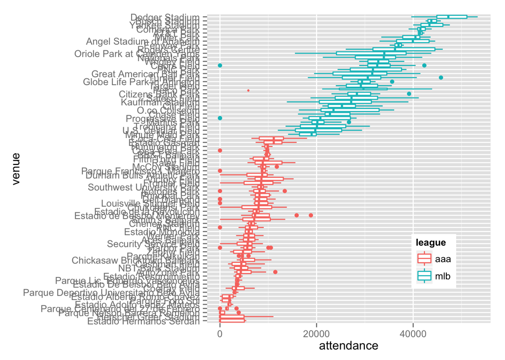

```r
boxscore <- collapse_obs(scores)
# transform attendance from a character string to an integer
attendance <- as.integer(gsub("\\,", "", boxscore[,"attendance"]))
venue <- boxscore[,"venue_name"]
parks <- names(sort(tapply(attendance, INDEX = venue, median)))
df <- data.frame(attendance, venue = factor(venue, levels = parks),
                 league = boxscore[,"home_sport_code"])
library(ggplot2)
qplot(data = df, x = venue, y = attendance, geom = "boxplot",
      color = league) + coord_flip() +
      theme(legend.position = c(0.8,0.2))
```